# Data Analyst Capstone

Atakan KÖREZ

05 11 2021

## Case Study: How Does a Bike-Share Navigate Speedy Success?

The purpose of this document is to consolidate downloaded Divvy data into a single dataframe and then conduct simple analysis to help answer the key question: “In what ways do members and casual riders use Divvy bikes differently?”

### Introduction

This exploratory analysis case study is towards Capstome project requirement for [Google Data Analytics Professional Certificate](https://www.coursera.org/professional-certificates/google-data-analytics). The case study involves a bikeshare company’s data of its customer’s trip details over a 12 month period (November 2020 - October 2021). The data has been made available by Motivate International Inc. under this [license](https://www.divvybikes.com/data-license-agreement).

The analysis will follow the 6 phases of the Data Analysis process: Ask, Prepare, Process, Analyze, and Act. A brief explanation of these processes:

#### Ask

- Ask effective questions
- Define the scope of the analysis
- Define what success looks like

#### Prepare

- Verify data’s integrity
- Check data credibility and reliability
- Check data types
- Merge datasets

#### Process

- Clean, Remove and Transform data
- Document cleaning processes and results

#### Analyze

- Identify patterns
- Draw conclusions
- Make predictions

#### Share

- Create effective visuals
- Create a story for data
- Share insights to stakeholders

#### Act

- Give recommendations based on insights
- Solve problems
- Create something new

### 1. Ask

#### Scenario

Marketing team needs to design marketing strategies aimed at converting casual riders into annual members. In order to do that, however, the marketing analyst team needs to better understand how annual members and casual riders differ.

#### Stakeholders:

- Director of marketing
- Cyclistic executive team

##### Objective

Hence, the objective for this analysis is to throw some light on how the two types of customers: annual members and casual riders, use Cyclistic bikeshare differently, based on few parameters that can be calculated/ obtained from existing data.

#### Deliverables:

- Insights on how annual members and casual riders use Cyclistic bikes differently
- Provide effective visuals and relevant data to support insights
- Use insights to give three recommendations to convert casual riders to member riders

### 2. Prepare

#### Data Source

A total of **12 CSV files** have been made available for each month starting from **November 2020 to October 2021**. Each file captures the details of every ride logged by the customers of Cyclistic. This data that has been made publicly available has been scrubbed to omit rider’s personal information.

The combined size of all the 12 CSV files is close to 950 MB. Data cleaning in spreadsheets will be time-consuming and slow compared to R. I am choosing R simply because I could do both data wrangling and analysis/ visualizations in the same platform.

#### Load Libraries

```r
library(tidyverse)
```

```r
library(ggplot2)
library(lubridate)
library(dplyr)
library(readr)
library(janitor)
library(data.table)
library(tidyr)
```

#### Load dataset CSV files (Previous 12 months of Cyclistic trip data)

```r
tripdata_202011 <- read.csv("~/Data_Analytics_Capstone/202011-divvy-tripdata.csv")
tripdata_202012 <- read.csv("~/Data_Analytics_Capstone/202012-divvy-tripdata.csv")
tripdata_202101 <- read.csv("~/Data_Analytics_Capstone/202101-divvy-tripdata.csv")
tripdata_202102 <- read.csv("~/Data_Analytics_Capstone/202102-divvy-tripdata.csv")
tripdata_202103 <- read.csv("~/Data_Analytics_Capstone/202103-divvy-tripdata.csv")
tripdata_202104 <- read.csv("~/Data_Analytics_Capstone/202104-divvy-tripdata.csv")
tripdata_202105 <- read.csv("~/Data_Analytics_Capstone/202105-divvy-tripdata.csv")
tripdata_202106 <- read.csv("~/Data_Analytics_Capstone/202106-divvy-tripdata.csv")
tripdata_202107 <- read.csv("~/Data_Analytics_Capstone/202107-divvy-tripdata.csv")
tripdata_202108 <- read.csv("~/Data_Analytics_Capstone/202108-divvy-tripdata.csv")
tripdata_202109 <- read.csv("~/Data_Analytics_Capstone/202109-divvy-tripdata.csv")
tripdata_202110 <- read.csv("~/Data_Analytics_Capstone/202110-divvy-tripdata.csv")
```

#### Data transformation and cleaning

start_station_id & end_station_id are not consistent in one CSV file. The ones in tripdata_202011 is int vs. the others are char. Convert the inconsistent ones from int to char datatype.

```r
tripdata_202011 <- tripdata_202011 %>% mutate(start_station_id = as.character(start_station_id), end_station_id = as.character(end_station_id))
```

### 3. Process

Combine all the datasets into one single dataframe

```r
all_trips <- bind_rows(tripdata_202011,tripdata_202012,tripdata_202101,tripdata_202102,tripdata_202103,tripdata_202104,tripdata_202105,tripdata_202106,tripdata_202107,tripdata_202108,tripdata_202109,  tripdata_202110)

str(all_trips)
```

```
## 'data.frame':    5378834 obs. of  13 variables:
##  $ ride_id           : chr  "BD0A6FF6FFF9B921" "96A7A7A4BDE4F82D" "C61526D06582BDC5" "E533E89C32080B9E" ...
##  $ rideable_type     : chr  "electric_bike" "electric_bike" "electric_bike" "electric_bike" ...
##  $ started_at        : chr  "2020-11-01 13:36:00" "2020-11-01 10:03:26" "2020-11-01 00:34:05" "2020-11-01 00:45:16" ...
##  $ ended_at          : chr  "2020-11-01 13:45:40" "2020-11-01 10:14:45" "2020-11-01 01:03:06" "2020-11-01 00:54:31" ...
##  $ start_station_name: chr  "Dearborn St & Erie St" "Franklin St & Illinois St" "Lake Shore Dr & Monroe St" "Leavitt St & Chicago Ave" ...
##  $ start_station_id  : chr  "110" "672" "76" "659" ...
##  $ end_station_name  : chr  "St. Clair St & Erie St" "Noble St & Milwaukee Ave" "Federal St & Polk St" "Stave St & Armitage Ave" ...
##  $ end_station_id    : chr  "211" "29" "41" "185" ...
##  $ start_lat         : num  41.9 41.9 41.9 41.9 41.9 ...
##  $ start_lng         : num  -87.6 -87.6 -87.6 -87.7 -87.6 ...
##  $ end_lat           : num  41.9 41.9 41.9 41.9 41.9 ...
##  $ end_lng           : num  -87.6 -87.7 -87.6 -87.7 -87.6 ...
##  $ member_casual     : chr  "casual" "casual" "casual" "casual" ...
```

#### Clean-up further!

Hold on! started_at & ended_at should be in datetime datatype instead of char. Convert all from char to datetime.

```r
all_trips[['started_at']] <- ymd_hms(all_trips[['started_at']])
all_trips[['ended_at']] <- ymd_hms(all_trips[['ended_at']])
```

#### Remove columns not required or beyond the scope of project

```r
all_trips <- all_trips %>%
  select(-c(start_lat:end_lng))

glimpse(all_trips)
```

```
## Rows: 5,378,834
## Columns: 9
## $ ride_id            <chr> "BD0A6FF6FFF9B921", "96A7A7A4BDE4F82D", "C61526D065~
## $ rideable_type      <chr> "electric_bike", "electric_bike", "electric_bike", ~
## $ started_at         <dttm> 2020-11-01 13:36:00, 2020-11-01 10:03:26, 2020-11-~
## $ ended_at           <dttm> 2020-11-01 13:45:40, 2020-11-01 10:14:45, 2020-11-~
## $ start_station_name <chr> "Dearborn St & Erie St", "Franklin St & Illinois St~
## $ start_station_id   <chr> "110", "672", "76", "659", "2", "72", "76", NA, "58~
## $ end_station_name   <chr> "St. Clair St & Erie St", "Noble St & Milwaukee Ave~
## $ end_station_id     <chr> "211", "29", "41", "185", "2", "76", "72", NA, "288~
## $ member_casual      <chr> "casual", "casual", "casual", "casual", "casual", "~
```

#### Rename columns for better readability

```r
all_trips <- all_trips %>%
  rename(ride_type = rideable_type,
         start_time = started_at,
         end_time = ended_at,
         customer_type = member_casual)

glimpse(all_trips)
```

```
## Rows: 5,378,834
## Columns: 9
## $ ride_id            <chr> "BD0A6FF6FFF9B921", "96A7A7A4BDE4F82D", "C61526D065~
## $ ride_type          <chr> "electric_bike", "electric_bike", "electric_bike", ~
## $ start_time         <dttm> 2020-11-01 13:36:00, 2020-11-01 10:03:26, 2020-11-~
## $ end_time           <dttm> 2020-11-01 13:45:40, 2020-11-01 10:14:45, 2020-11-~
## $ start_station_name <chr> "Dearborn St & Erie St", "Franklin St & Illinois St~
## $ start_station_id   <chr> "110", "672", "76", "659", "2", "72", "76", NA, "58~
## $ end_station_name   <chr> "St. Clair St & Erie St", "Noble St & Milwaukee Ave~
## $ end_station_id     <chr> "211", "29", "41", "185", "2", "76", "72", NA, "288~
## $ customer_type      <chr> "casual", "casual", "casual", "casual", "casual", "~
```

```r
# column for day of the week the trip started
all_trips$day_of_the_week <- format(as.Date(all_trips$start_time),'%a')
```

```r
# column for month when the trip started
all_trips$month <- format(as.Date(all_trips$start_time),'%b_%y')
```

```r
# The time is then converted back to POSIXct with today’s date – the date is of no interest to us,only the hours-minutes-seconds are.
all_trips$time <- format(all_trips$start_time, format = "%H:%M")
all_trips$time <- as.POSIXct(all_trips$time, format = "%H:%M")
```

```r
# column for trip duration in min
all_trips$trip_duration <- (as.double(difftime(all_trips$end_time, all_trips$start_time)))/60
```

```r
# check the dataframe
glimpse(all_trips)
```

```
## Rows: 5,378,834
## Columns: 13
## $ ride_id            <chr> "BD0A6FF6FFF9B921", "96A7A7A4BDE4F82D", "C61526D065~
## $ ride_type          <chr> "electric_bike", "electric_bike", "electric_bike", ~
## $ start_time         <dttm> 2020-11-01 13:36:00, 2020-11-01 10:03:26, 2020-11-~
## $ end_time           <dttm> 2020-11-01 13:45:40, 2020-11-01 10:14:45, 2020-11-~
## $ start_station_name <chr> "Dearborn St & Erie St", "Franklin St & Illinois St~
## $ start_station_id   <chr> "110", "672", "76", "659", "2", "72", "76", NA, "58~
## $ end_station_name   <chr> "St. Clair St & Erie St", "Noble St & Milwaukee Ave~
## $ end_station_id     <chr> "211", "29", "41", "185", "2", "76", "72", NA, "288~
## $ customer_type      <chr> "casual", "casual", "casual", "casual", "casual", "~
## $ day_of_the_week    <chr> "Paz", "Paz", "Paz", "Paz", "Paz", "Cmt", "Cmt", "C~
## $ month              <chr> "Kas_20", "Kas_20", "Kas_20", "Kas_20", "Kas_20", "~
## $ time               <dttm> 2021-11-06 13:36:00, 2021-11-06 10:03:00, 2021-11-~
## $ trip_duration      <dbl> 9.6666667, 11.3166667, 29.0166667, 9.2500000, 33.45~
```

Let’s check to see if the trip_duration column has any negative values, as this may cause problem while creating visualizations. Also, we do not want to include the trips that were part of quality tests by the company. These trips are usually identified by string ‘test’ in the start_station_name column.

```r
# checking for trip lengths less than 0
nrow(subset(all_trips,trip_duration < 0))
```

```
## [1] 1393
```

```r
#checking for testrides that were made by company for quality checks
nrow(subset(all_trips, start_station_name %like% "TEST"))
```

```
## [1] 105
```

```r
nrow(subset(all_trips, start_station_name %like% "test"))
```

```
## [1] 0
```

```r
nrow(subset(all_trips, start_station_name %like% "Test"))
```

```
## [1] 0
```

```r
# remove negative trip durations
all_trips_v2 <- all_trips[!(all_trips$trip_duration < 0),]

#remove test rides
all_trips_v2<- all_trips_v2[!((all_trips_v2$start_station_name %like% "TEST" | all_trips_v2$start_station_name %like% "test")),]

#check dataframe
glimpse(all_trips_v2)
```

```
## Rows: 5,377,336
## Columns: 13
## $ ride_id            <chr> "BD0A6FF6FFF9B921", "96A7A7A4BDE4F82D", "C61526D065~
## $ ride_type          <chr> "electric_bike", "electric_bike", "electric_bike", ~
## $ start_time         <dttm> 2020-11-01 13:36:00, 2020-11-01 10:03:26, 2020-11-~
## $ end_time           <dttm> 2020-11-01 13:45:40, 2020-11-01 10:14:45, 2020-11-~
## $ start_station_name <chr> "Dearborn St & Erie St", "Franklin St & Illinois St~
## $ start_station_id   <chr> "110", "672", "76", "659", "2", "72", "76", NA, "58~
## $ end_station_name   <chr> "St. Clair St & Erie St", "Noble St & Milwaukee Ave~
## $ end_station_id     <chr> "211", "29", "41", "185", "2", "76", "72", NA, "288~
## $ customer_type      <chr> "casual", "casual", "casual", "casual", "casual", "~
## $ day_of_the_week    <chr> "Paz", "Paz", "Paz", "Paz", "Paz", "Cmt", "Cmt", "C~
## $ month              <chr> "Kas_20", "Kas_20", "Kas_20", "Kas_20", "Kas_20", "~
## $ time               <dttm> 2021-11-06 13:36:00, 2021-11-06 10:03:00, 2021-11-~
## $ trip_duration      <dbl> 9.6666667, 11.3166667, 29.0166667, 9.2500000, 33.45~
```

It is important to make sure that customer_type column has only two distinct values. Let’s confirm the same.

```r
# checking count of distinct values
table(all_trips_v2$customer_type)
```

```
##
##  casual  member
## 2470117 2907219
```

```r
#aggregating total trip duration by customer type
setNames(aggregate(trip_duration ~ customer_type, all_trips_v2, sum), c("customer_type", "total_trip_duration(mins)"))
```

```
##   customer_type total_trip_duration(mins)
## 1        casual                  80423286
## 2        member                  40594097
```

### 4&5. Analyze and Share Data

The dataframe is now ready for descriptive analysis that will help us uncover some insights on how the casual riders and members use Cyclistic rideshare differently.

First, let’s try to get some simple statistics on trip_duration for all customers, and do the same by customer_type.

```r
# statictical summary of trip_duration for all trips
summary(all_trips_v2$trip_duration)
```

```
##     Min.  1st Qu.   Median     Mean  3rd Qu.     Max.
##     0.00     6.97    12.38    22.51    22.43 55944.15
```

```r
#statistical summary of trip_duration by customer_type
all_trips_v2 %>%
  group_by(customer_type) %>%
  summarise(min_trip_duration = min(trip_duration),max_trip_duration = max(trip_duration),
            median_trip_duration = median(trip_duration), mean_trip_duration = mean(trip_duration))
```

```
## # A tibble: 2 x 5
##   customer_type min_trip_duration max_trip_duration median_trip_duration
##   <chr>                     <dbl>             <dbl>                <dbl>
## 1 casual                        0            55944.                16.4
## 2 member                        0             1560.                 9.92
## # ... with 1 more variable: mean_trip_duration <dbl>
```

The mean trip duration of member riders is lower than the mean trip duration of all trips, while it is exactly the opposite for casual riders, whose mean trip duration is higher than the the mean trip duration of all trips. This tells us that casual riders usually take the bikes out for a longer duration compared to members.

#### Total number of trips by customer type and day of the week

```r
# fix the order for the day_of_the_week and month variable so that they show up in the same sequence in output tables and visualizations
all_trips_v2$day_of_the_week <- ordered(all_trips_v2$day_of_the_week, levels=c("Pzt", "Sal", "Çar", "Per", "Cum", "Cmt", "Paz"))

all_trips_v2$month <- ordered(all_trips_v2$month, levels=c("Kas_20","Ara_20","Oca_21","Şub_21","Mar_21",                      "Nis_21", "May_21","Haz_21","Tem_21", "Ağu_21",                    "Eyl_21","Eki_21"))

#Total number of trips by customer type and day of the week

all_trips_v2 %>%
  group_by(customer_type, day_of_the_week) %>%
  summarise(number_of_rides = n(),average_duration_mins = mean(trip_duration)) %>%
  arrange(customer_type, desc(number_of_rides))
```

```
## # A tibble: 14 x 4
## # Groups:   customer_type [2]
##    customer_type day_of_the_week number_of_rides average_duration_mins
##    <chr>         <ord>                     <int>                 <dbl>
##  1 casual        Cmt                      551814                  35.2
##  2 casual        Paz                      476138                  38.1
##  3 casual        Cum                      354955                  30.9
##  4 casual        Pzt                      278245                  32.3
##  5 casual        Per                      277310                  28.2
##  6 casual        Çar                      267431                  28.2
##  7 casual        Sal                      264224                  28.6
##  8 member        Çar                      444255                  13.2
##  9 member        Sal                      431459                  13.1
## 10 member        Per                      425562                  13.1
## 11 member        Cum                      425119                  13.7
## 12 member        Cmt                      421164                  15.6
## 13 member        Pzt                      391286                  13.5
## 14 member        Paz                      368374                  15.9
```

#### Visualization

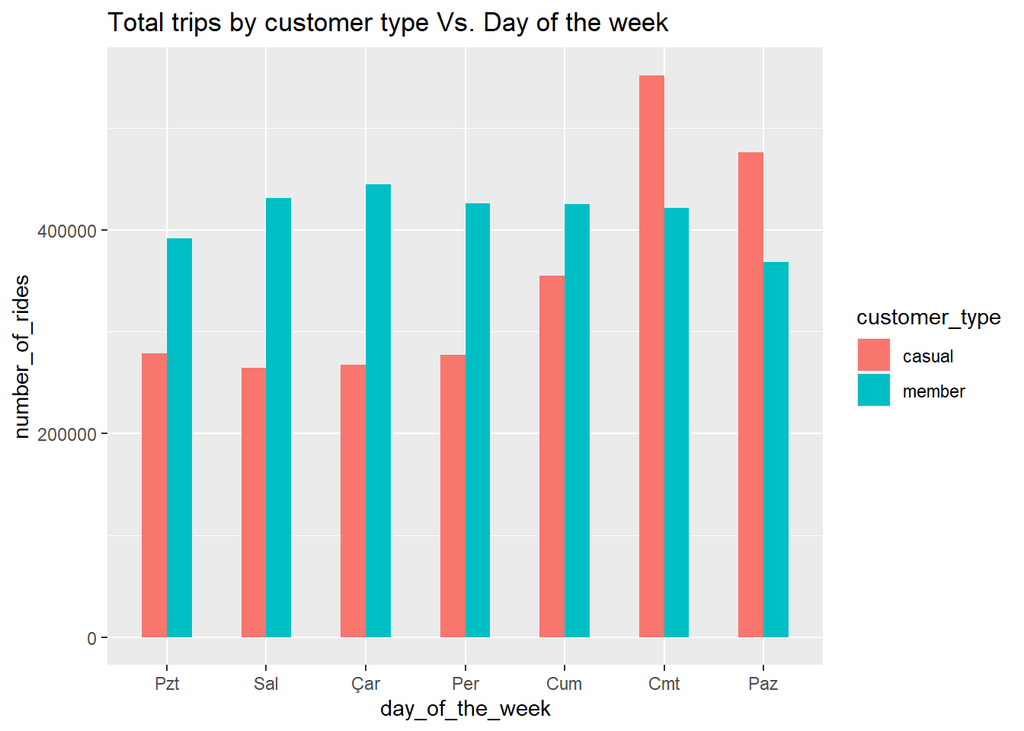

```r
#Total trips by customer type Vs. Day_of_Week
all_trips_v2 %>%
  group_by(customer_type, day_of_the_week) %>%
  summarise(number_of_rides = n()) %>%
  arrange(customer_type, day_of_the_week)  %>%
  ggplot(aes(x = day_of_the_week, y = number_of_rides, fill = customer_type)) +
  labs(title ="Total trips by customer type Vs. Day of the week") +
  geom_col(width=0.5, position = position_dodge(width=0.5)) +
  scale_y_continuous(labels = function(x) format(x, scientific = FALSE))
```

```r
all_trips_v2 %>%
  group_by(customer_type, month) %>%
  summarise(number_of_rides = n(),`average_duration_(mins)` = mean(trip_duration)) %>%
  arrange(customer_type,desc(number_of_rides))
```

```
## # A tibble: 24 x 4
## # Groups:   customer_type [2]
##    customer_type month  number_of_rides `average_duration_(mins)`
##    <chr>         <ord>            <int>                     <dbl>
##  1 casual        Tem_21          442048                      32.8
##  2 casual        Ağu_21          412662                      28.8
##  3 casual        Haz_21          370678                      37.1
##  4 casual        Eyl_21          363883                      27.8
##  5 casual        Eki_21          257242                      28.7
##  6 casual        May_21          256916                      38.2
##  7 casual        Nis_21          136601                      38.0
##  8 casual        Kas_20           87810                      31.9
##  9 casual        Mar_21           84032                      38.2
## 10 casual        Ara_20           29997                      26.8
## # ... with 14 more rows
```

#### Visualization

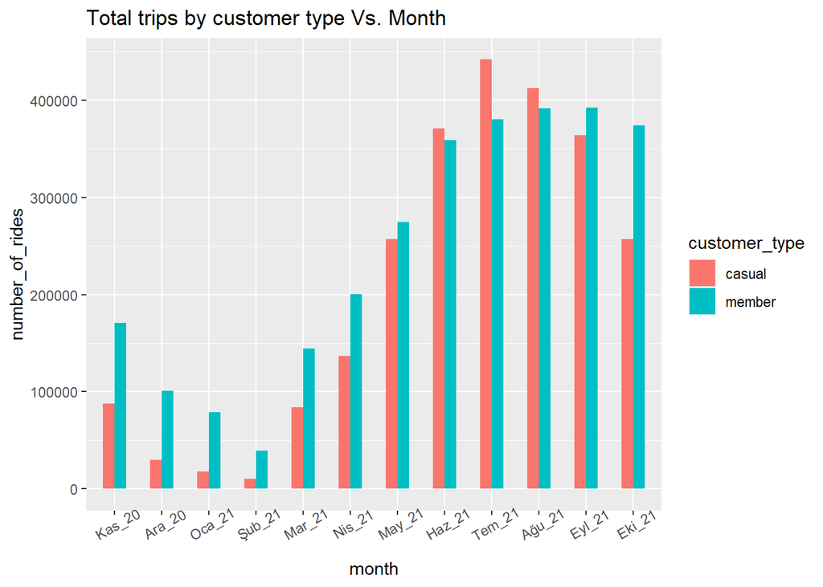

```r
#Total trips by customer type Vs. Month
all_trips_v2 %>%
  group_by(customer_type, month) %>%
  summarise(number_of_rides = n()) %>%
  arrange(customer_type, month)  %>%
  ggplot(aes(x = month, y = number_of_rides, fill = customer_type)) +
  labs(title ="Total trips by customer type Vs. Month") +
  theme(axis.text.x = element_text(angle = 30)) +
  geom_col(width=0.5, position = position_dodge(width=0.5)) +
  scale_y_continuous(labels = function(x) format(x, scientific = FALSE))
```

#### Visualizaton of average trip duration by customer type on each day of the week

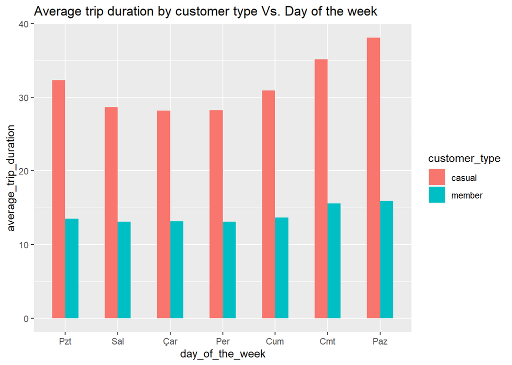

```r
all_trips_v2 %>%
  group_by(customer_type, day_of_the_week) %>%
  summarise(average_trip_duration = mean(trip_duration)) %>%
  ggplot(aes(x = day_of_the_week, y = average_trip_duration, fill = customer_type)) +
  geom_col(width=0.5, position = position_dodge(width=0.5)) +
  labs(title ="Average trip duration by customer type Vs. Day of the week")
```

#### Visualizaton of average trip duration by customer type Vs. month

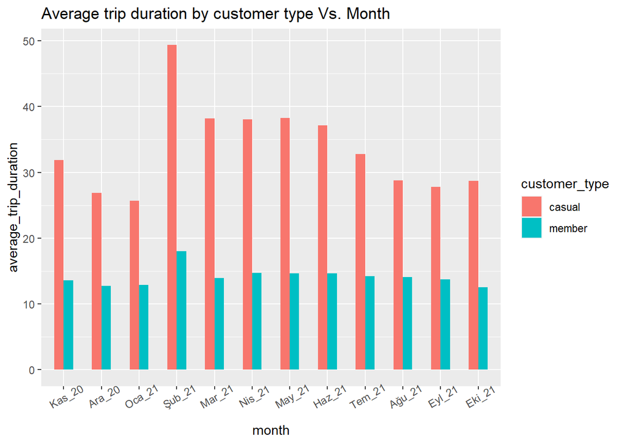

```r
all_trips_v2 %>%
  group_by(customer_type, month) %>%
  summarise(average_trip_duration = mean(trip_duration)) %>%
  ggplot(aes(x = month, y = average_trip_duration, fill = customer_type)) +
  geom_col(width=0.5, position = position_dodge(width=0.5)) +
  labs(title ="Average trip duration by customer type Vs. Month") +
  theme(axis.text.x = element_text(angle = 30))
```

#### Visualizaton of bike demand over 24 hr period (a day)

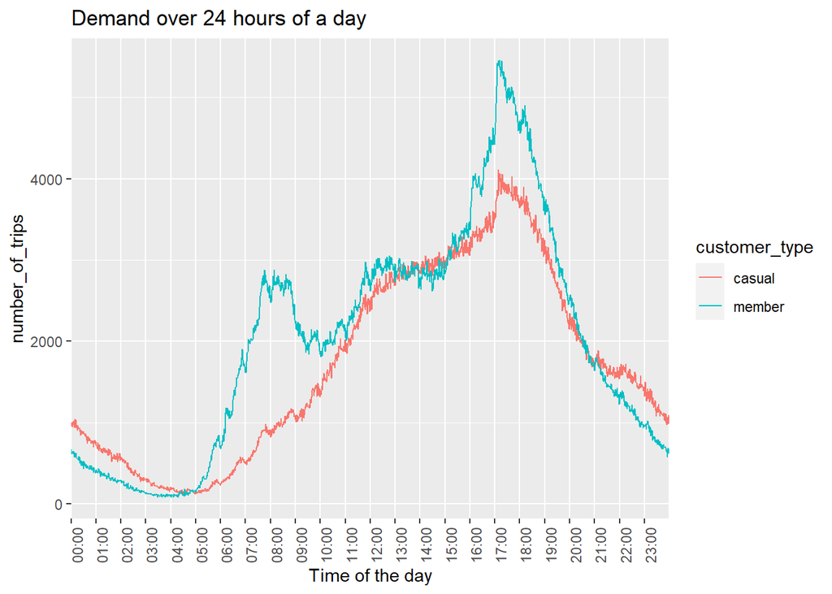

```r
all_trips_v2 %>%
  group_by(customer_type, time) %>%
  summarise(number_of_trips = n()) %>%
  ggplot(aes(x = time, y = number_of_trips, color = customer_type, group = customer_type)) +
  geom_line() +
  scale_x_datetime(date_breaks = "1 hour", minor_breaks = NULL,
                   date_labels = "%H:%M", expand = c(0,0)) +
  theme(axis.text.x = element_text(angle = 90)) +
  labs(title ="Demand over 24 hours of a day", x = "Time of the day")
```

For the members, there seems to be two distict peak demand hours: 7-9 AM and 5-7 PM, the latter one coinciding with the peak demand hours of casual riders as well. One could probably hypothesize that office-goers make up majority of the members profile due to demand in both morning and evening hours, but we need more data to substabtiate this assumption.

#### Visualizaton of ride type Vs. number of trips by customer type

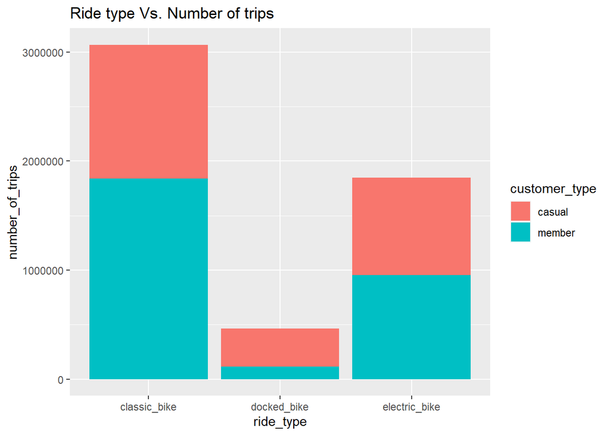

```r
all_trips_v2 %>%
  group_by(ride_type, customer_type) %>%
  summarise(number_of_trips = n()) %>%
  ggplot(aes(x= ride_type, y=number_of_trips, fill= customer_type))+
  geom_bar(stat='identity') +
  scale_y_continuous(labels = function(x) format(x, scientific = FALSE)) +
  labs(title ="Ride type Vs. Number of trips")
```

### Recommendations

- Provide attractive promotions for casual riders on weekdays so that casual members use the bikeshare services ore uniformly across the entire week.
- Offer discounted membership fee for renewals after the first year. It might nudge casual riders to take up membership.
- Offer discounted pricing during non-busy hours so that casual riders might choose to use bikes more often and level out demand over the day.

### Additonal data that could expand scope of analysis

- Age and gender profile - Again, this data could be used to study the category of riders who can be targeted for attracting new members.
- Address/ neighborhood details of members to investigate if there are any location specific parameters that encourage membership.
- Pricing details for members and casual riders - Based on this data, we might be to optimize cost structure for casual riders or provide discounts without affecting the profit margin.